# Sales Analysis

```python
import pandas as pd
import numpy as np
import os
```

#### Merging 12 Months of Sales Data into a single file

```python
#To do this we First read the single month's Data

df = pd.read_csv('./Sales_data/Sales_April_2019.csv')
```

```python
df.head()
```

|  | Order ID | Product | Quantity Ordered | Price Each | Order Date | Purchase Address |
| --- | --- | --- | --- | --- | --- | --- |
| 0 | 176558 | USB-C Charging Cable | 2 | 11.95 | 04/19/19 08:46 | 917 1st St, Dallas, TX 75001 |
| 1 | NaN | NaN | NaN | NaN | NaN | NaN |
| 2 | 176559 | Bose SoundSport Headphones | 1 | 99.99 | 04/07/19 22:30 | 682 Chestnut St, Boston, MA 02215 |
| 3 | 176560 | Google Phone | 1 | 600 | 04/12/19 14:38 | 669 Spruce St, Los Angeles, CA 90001 |
| 4 | 176560 | Wired Headphones | 1 | 11.99 | 04/12/19 14:38 | 669 Spruce St, Los Angeles, CA 90001 |

```python
#How to read all Files from the Dir
#All our Sales data files are in the Folder Sales_data in the Current Directory

files = [file for file in os.listdir('./Sales_data')]

for file in files:
    print(file)
```

```
Sales_April_2019.csv
Sales_August_2019.csv
Sales_December_2019.csv
Sales_February_2019.csv
Sales_January_2019.csv
Sales_July_2019.csv
Sales_June_2019.csv
Sales_March_2019.csv
Sales_May_2019.csv
Sales_November_2019.csv
Sales_October_2019.csv
Sales_September_2019.csv
```

```python
#Checking the Shape of each File

files = [file for file in os.listdir('./Sales_data')]

for file in files:
    print(file)
    df = pd.read_csv("./Sales_data/" + file)
    print(df.shape)
```

```
Sales_April_2019.csv
(18383, 6)
Sales_August_2019.csv
(12011, 6)
Sales_December_2019.csv
(25117, 6)
Sales_February_2019.csv
(12036, 6)
Sales_January_2019.csv
(9723, 6)
Sales_July_2019.csv
(14371, 6)
Sales_June_2019.csv
(13622, 6)
Sales_March_2019.csv
(15226, 6)
Sales_May_2019.csv
(16635, 6)
Sales_November_2019.csv
(17661, 6)
Sales_October_2019.csv
(20379, 6)
Sales_September_2019.csv
(11686, 6)
```

```python
#Now we concatenate them to make a Single csv
```

```python
#This is how we go ahead and create Empty DataFrame

all_months_data = pd.DataFrame()
```

```python
all_months_data
```

#### 🛑Problem With the Below code:

- There will be Headers for all the 12 Files in the Dataset

```python
#How to read all Files from the Dir
#All our Sales data files are in the Folder Sales_data in the Current Directory
#We want to append all the Data Frames  "all_months_data"
#df = pd.read_csv("./Sales_data/" + file) : will read all the File names as dataframes
#This code has all the File Names : files = [file for file in os.listdir('./Sales_data')]
# Sales_April_2019.csv
# Sales_August_2019.csv
# Sales_December_2019.csv
# Sales_February_2019.csv
# Sales_January_2019.csv
# Sales_July_2019.csv
# Sales_June_2019.csv
# Sales_March_2019.csv
# Sales_May_2019.csv
# Sales_November_2019.csv
# Sales_October_2019.csv
# Sales_September_2019.csv

files = [file for file in os.listdir('./Sales_data')]

all_months_data = pd.DataFrame() #This is just an Empty Data frame

for file in files:
    df = pd.read_csv("./Sales_data/" + file)
    all_months_data = pd.concat([all_months_data, df])

all_months_data.head()
```

|  | Order ID | Product | Quantity Ordered | Price Each | Order Date | Purchase Address |
| --- | --- | --- | --- | --- | --- | --- |
| 0 | 176558 | USB-C Charging Cable | 2 | 11.95 | 04/19/19 08:46 | 917 1st St, Dallas, TX 75001 |
| 1 | NaN | NaN | NaN | NaN | NaN | NaN |
| 2 | 176559 | Bose SoundSport Headphones | 1 | 99.99 | 04/07/19 22:30 | 682 Chestnut St, Boston, MA 02215 |
| 3 | 176560 | Google Phone | 1 | 600 | 04/12/19 14:38 | 669 Spruce St, Los Angeles, CA 90001 |
| 4 | 176560 | Wired Headphones | 1 | 11.99 | 04/12/19 14:38 | 669 Spruce St, Los Angeles, CA 90001 |

```python
all_months_data.shape
```

```
(186850, 6)
```

Concat VS Merge

https://towardsdatascience.com/3-key-differences-between-merge-and-concat-functions-of-pandas-ab2bab224b59#:~:text=Concat%20function%20concatenates%20dataframes%20along,combinations%20based%20on%20a%20condition.

#### Either we can export the Dataset as csv and remove all Headers except First Row:

```python
all_months_data = all_months_data.dropna().reset_index(drop = True)
```

```python
all_months_data.loc[all_months_data['Order Date'].str.len() < 12]
```

|  | Order ID | Product | Quantity Ordered | Price Each | Order Date | Purchase Address |
| --- | --- | --- | --- | --- | --- | --- |
| 517 | Order ID | Product | Quantity Ordered | Price Each | Order Date | Purchase Address |
| 1146 | Order ID | Product | Quantity Ordered | Price Each | Order Date | Purchase Address |
| 1152 | Order ID | Product | Quantity Ordered | Price Each | Order Date | Purchase Address |
| 2869 | Order ID | Product | Quantity Ordered | Price Each | Order Date | Purchase Address |
| 2884 | Order ID | Product | Quantity Ordered | Price Each | Order Date | Purchase Address |
| ... | ... | ... | ... | ... | ... | ... |
| 184624 | Order ID | Product | Quantity Ordered | Price Each | Order Date | Purchase Address |
| 185009 | Order ID | Product | Quantity Ordered | Price Each | Order Date | Purchase Address |
| 186019 | Order ID | Product | Quantity Ordered | Price Each | Order Date | Purchase Address |
| 186088 | Order ID | Product | Quantity Ordered | Price Each | Order Date | Purchase Address |
| 186194 | Order ID | Product | Quantity Ordered | Price Each | Order Date | Purchase Address |

355 rows × 6 columns

```python
#We can check the data by exporting it as csv
#all_months_data.to_csv("all_data.csv", index = False)
```

```python
all_months_data.loc[all_months_data['Order ID'].str.lower().str.contains('order')]
```

|  | Order ID | Product | Quantity Ordered | Price Each | Order Date | Purchase Address |
| --- | --- | --- | --- | --- | --- | --- |
| 517 | Order ID | Product | Quantity Ordered | Price Each | Order Date | Purchase Address |
| 1146 | Order ID | Product | Quantity Ordered | Price Each | Order Date | Purchase Address |
| 1152 | Order ID | Product | Quantity Ordered | Price Each | Order Date | Purchase Address |
| 2869 | Order ID | Product | Quantity Ordered | Price Each | Order Date | Purchase Address |
| 2884 | Order ID | Product | Quantity Ordered | Price Each | Order Date | Purchase Address |
| ... | ... | ... | ... | ... | ... | ... |
| 184624 | Order ID | Product | Quantity Ordered | Price Each | Order Date | Purchase Address |
| 185009 | Order ID | Product | Quantity Ordered | Price Each | Order Date | Purchase Address |
| 186019 | Order ID | Product | Quantity Ordered | Price Each | Order Date | Purchase Address |
| 186088 | Order ID | Product | Quantity Ordered | Price Each | Order Date | Purchase Address |
| 186194 | Order ID | Product | Quantity Ordered | Price Each | Order Date | Purchase Address |

355 rows × 6 columns

```python
all_months_data.drop(all_months_data.index[all_months_data['Order ID'].str.lower().str.contains('order')], inplace = True)
```

```python
all_months_data.head(3)
```

|  | Order ID | Product | Quantity Ordered | Price Each | Order Date | Purchase Address |
| --- | --- | --- | --- | --- | --- | --- |
| 0 | 176558 | USB-C Charging Cable | 2 | 11.95 | 04/19/19 08:46 | 917 1st St, Dallas, TX 75001 |
| 1 | 176559 | Bose SoundSport Headphones | 1 | 99.99 | 04/07/19 22:30 | 682 Chestnut St, Boston, MA 02215 |
| 2 | 176560 | Google Phone | 1 | 600 | 04/12/19 14:38 | 669 Spruce St, Los Angeles, CA 90001 |

### Analysis

#### Question 1 : What was the best Month for Sales? How much was earned that Month ?

Before we go on to the Analysis , we can Add some more columns.

We can extract the Month from the "Order Date"

#### Augment Data wityh additional Columns:

#### Add Month column

```python
#We can either extract the Month with the datetime
#We can also use string methods on Order Date to extract the first 2 numbers
```

```python
import datetime
```

```python
all_months_data['Order Date'].dtype
```

```
dtype('O')
```

```python
all_months_data.info()
```

```
<class 'pandas.core.frame.DataFrame'>
Int64Index: 185950 entries, 0 to 186304
Data columns (total 6 columns):
 #   Column            Non-Null Count   Dtype
---  ------            --------------   -----
 0   Order ID          185950 non-null  object
 1   Product           185950 non-null  object
 2   Quantity Ordered  185950 non-null  object
 3   Price Each        185950 non-null  object
 4   Order Date        185950 non-null  object
 5   Purchase Address  185950 non-null  object
dtypes: object(6)
memory usage: 9.9+ MB
```

```python
#all_months_data['Order Date'] =  pd.to_datetime(all_months_data['Order Date'].str.strip(), format='%m/%d/%Y %H:%M')
```

```python
all_months_data.isnull().sum()
```

```
Order ID            0
Product             0
Quantity Ordered    0
Price Each          0
Order Date          0
Purchase Address    0
dtype: int64
```

```python
all_months_data.shape
```

```
(185950, 6)
```

```python
all_months_data['Order Date'] =  pd.to_datetime(all_months_data['Order Date'])
```

```python
all_months_data.head(2)
```

|  | Order ID | Product | Quantity Ordered | Price Each | Order Date | Purchase Address |
| --- | --- | --- | --- | --- | --- | --- |
| 0 | 176558 | USB-C Charging Cable | 2 | 11.95 | 2019-04-19 08:46:00 | 917 1st St, Dallas, TX 75001 |
| 1 | 176559 | Bose SoundSport Headphones | 1 | 99.99 | 2019-04-07 22:30:00 | 682 Chestnut St, Boston, MA 02215 |

```python
all_months_data['Order Date']=all_months_data['Order Date'].str[0:8]
```

```python
all_months_data.head(2)
```

[output not shown]

```python
all_months_data.info()
```

```
<class 'pandas.core.frame.DataFrame'>
Int64Index: 185950 entries, 0 to 186304
Data columns (total 6 columns):
 #   Column            Non-Null Count   Dtype
---  ------            --------------   -----
 0   Order ID          185950 non-null  object
 1   Product           185950 non-null  object
 2   Quantity Ordered  185950 non-null  object
 3   Price Each        185950 non-null  object
 4   Order Date        185950 non-null  datetime64[ns]
 5   Purchase Address  185950 non-null  object
dtypes: datetime64[ns](1), object(5)
memory usage: 9.9+ MB
```

```python
all_months_data['Order Date'] = all_months_data['Order Date'].astype('datetime64[ns]')
```

```python
from datetime import datetime
```

```python
all_months_data['Order Date'] = all_months_data['Order Date'].dt.strftime('%m/%d/%Y')
```

```python
all_months_data.head(2)
```

|  | Order ID | Product | Quantity Ordered | Price Each | Order Date | Purchase Address |
| --- | --- | --- | --- | --- | --- | --- |
| 0 | 176558 | USB-C Charging Cable | 2 | 11.95 | 04/19/2019 | 917 1st St, Dallas, TX 75001 |
| 1 | 176559 | Bose SoundSport Headphones | 1 | 99.99 | 04/07/2019 | 682 Chestnut St, Boston, MA 02215 |

```python
#pandas datetimeindex docs: https://pandas.pydata.org/pandas-docs/stable/generated/pandas.DatetimeIndex.html
all_months_data['Order Date_Month'] = pd.DatetimeIndex(all_months_data['Order Date']).month
all_months_data.head(2)
```

|  | Order ID | Product | Quantity Ordered | Price Each | Order Date | Purchase Address | Order Date_Month |
| --- | --- | --- | --- | --- | --- | --- | --- |
| 0 | 176558 | USB-C Charging Cable | 2 | 11.95 | 04/19/2019 | 917 1st St, Dallas, TX 75001 | 4 |
| 1 | 176559 | Bose SoundSport Headphones | 1 | 99.99 | 04/07/2019 | 682 Chestnut St, Boston, MA 02215 | 4 |

```python
all_months_data.info()
```

[output not shown]

#### What was the best month for Sales ? How much was earned that Month?

#### Add a Sales Column first

```python
all_months_data['Quantity Ordered'] = all_months_data['Quantity Ordered'].astype('int')
```

```python
all_months_data['Price Each'] = all_months_data['Price Each'].astype('float')
```

```python
all_months_data['Sales'] = all_months_data['Quantity Ordered'] * all_months_data['Price Each']
```

```python
all_months_data.head(2)
```

|  | Order ID | Product | Quantity Ordered | Price Each | Order Date | Purchase Address | Order Date_Month | Sales |
| --- | --- | --- | --- | --- | --- | --- | --- | --- |
| 0 | 176558 | USB-C Charging Cable | 2 | 11.95 | 2019-04-19 | 917 1st St, Dallas, TX 75001 | 4 | 23.90 |
| 1 | 176559 | Bose SoundSport Headphones | 1 | 99.99 | 2019-04-07 | 682 Chestnut St, Boston, MA 02215 | 4 | 99.99 |

```python
all_months_data['Price Each']=all_months_data['Price Each'].round(2)
```

```python
results = all_months_data.groupby('Order Date_Month').sum()
```

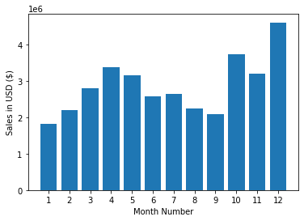

```python
import matplotlib.pyplot as plt

months = range(1, 13)

plt.bar(months, results['Sales'])
plt.xticks(months)
plt.ylabel('Sales in USD ($)')
plt.xlabel('Month Number')
plt.show()
```

### What City has the highest number of Sales?

### Add a City Column

```python
#Lets use the .apply method
```

```python
#Apply Method allows us to run any function on the Data Frame
```

```python
all_months_data.head(2)
```

|  | Order ID | Product | Quantity Ordered | Price Each | Order Date | Purchase Address | Order Date_Month | Sales |
| --- | --- | --- | --- | --- | --- | --- | --- | --- |
| 0 | 176558 | USB-C Charging Cable | 2 | 11.95 | 2019-04-19 | 917 1st St, Dallas, TX 75001 | 4 | 23.90 |
| 1 | 176559 | Bose SoundSport Headphones | 1 | 99.99 | 2019-04-07 | 682 Chestnut St, Boston, MA 02215 | 4 | 99.99 |

```python
#We can split the Text on these 2 Commas and grab the second string (that is index 1)
```

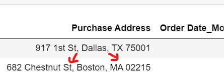

```python
all_months_data['Column'] = all_months_data['Purchase Address'].apply(lambda x: x.split(',')[1])
```

```python
all_months_data.head(5)
```

|  | Order ID | Product | Quantity Ordered | Price Each | Order Date | Purchase Address | Order Date_Month | Sales | Column |
| --- | --- | --- | --- | --- | --- | --- | --- | --- | --- |
| 0 | 176558 | USB-C Charging Cable | 2 | 11.95 | 2019-04-19 | 917 1st St, Dallas, TX 75001 | 4 | 23.90 | Dallas |
| 1 | 176559 | Bose SoundSport Headphones | 1 | 99.99 | 2019-04-07 | 682 Chestnut St, Boston, MA 02215 | 4 | 99.99 | Boston |
| 2 | 176560 | Google Phone | 1 | 600.00 | 2019-04-12 | 669 Spruce St, Los Angeles, CA 90001 | 4 | 600.00 | Los Angeles |
| 3 | 176560 | Wired Headphones | 1 | 11.99 | 2019-04-12 | 669 Spruce St, Los Angeles, CA 90001 | 4 | 11.99 | Los Angeles |
| 4 | 176561 | Wired Headphones | 1 | 11.99 | 2019-04-30 | 333 8th St, Los Angeles, CA 90001 | 4 | 11.99 | Los Angeles |

### We can also Define a Function and use it in Apply method as below:

```python
def get_city(address):
    return address.split(',')[1]
```

```python
all_months_data['New_Column'] = all_months_data['Purchase Address'].apply(lambda x: get_city(x))
```

```python
all_months_data.head(2)
```

|  | Order ID | Product | Quantity Ordered | Price Each | Order Date | Purchase Address | Order Date_Month | Sales | Column | New_Column |
| --- | --- | --- | --- | --- | --- | --- | --- | --- | --- | --- |
| 0 | 176558 | USB-C Charging Cable | 2 | 11.95 | 2019-04-19 | 917 1st St, Dallas, TX 75001 | 4 | 23.90 | Dallas | Dallas |
| 1 | 176559 | Bose SoundSport Headphones | 1 | 99.99 | 2019-04-07 | 682 Chestnut St, Boston, MA 02215 | 4 | 99.99 | Boston | Boston |

```python
#We should actually ceate the City Column with the above function
all_months_data['city'] = all_months_data['Purchase Address'].apply(lambda x: get_city(x))
```

```python
all_months_data.head(2)
```

|  | Order ID | Product | Quantity Ordered | Price Each | Order Date | Purchase Address | Order Date_Month | Sales | Column | New_Column | city |
| --- | --- | --- | --- | --- | --- | --- | --- | --- | --- | --- | --- |
| 0 | 176558 | USB-C Charging Cable | 2 | 11.95 | 2019-04-19 | 917 1st St, Dallas, TX 75001 | 4 | 23.90 | Dallas | Dallas | Dallas |
| 1 | 176559 | Bose SoundSport Headphones | 1 | 99.99 | 2019-04-07 | 682 Chestnut St, Boston, MA 02215 | 4 | 99.99 | Boston | Boston | Boston |

```python
#We can drop "Column" and "New_Column"
```

```python
all_months_data = all_months_data.drop(columns = 'Column')
```

```python
all_months_data = all_months_data.drop(columns = 'New_Column')
```

```python
#Alternatively
#all_months_data.drop(columns = 'Column', inplace = True)
```

```python
all_months_data.head(2)
```

|  | Order ID | Product | Quantity Ordered | Price Each | Order Date | Purchase Address | Order Date_Month | Sales | city |
| --- | --- | --- | --- | --- | --- | --- | --- | --- | --- |
| 0 | 176558 | USB-C Charging Cable | 2 | 11.95 | 2019-04-19 | 917 1st St, Dallas, TX 75001 | 4 | 23.90 | Dallas |
| 1 | 176559 | Bose SoundSport Headphones | 1 | 99.99 | 2019-04-07 | 682 Chestnut St, Boston, MA 02215 | 4 | 99.99 | Boston |

### If we want to have State + Zip Code

Sometimes , you need to verify the City Name properly , so you would want to have even the State

```python
#Lets say we also want to have the State and Zip code
```

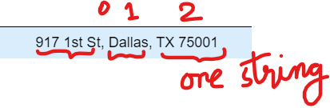

```python
def get_state(address):
    x=address.split(',')[1]  #Splitting at first occurance of comma
    y=address.split(',')[2]  #Splitting at Second occurance of comma
    return(x + " " + y)

all_months_data['city'] = all_months_data['Purchase Address'].apply(lambda x:get_state(x))
```

```python
all_months_data.head(3)
```

|  | Order ID | Product | Quantity Ordered | Price Each | Order Date | Purchase Address | Order Date_Month | Sales | city |
| --- | --- | --- | --- | --- | --- | --- | --- | --- | --- |
| 0 | 176558 | USB-C Charging Cable | 2 | 11.95 | 2019-04-19 | 917 1st St, Dallas, TX 75001 | 4 | 23.90 | Dallas TX 75001 |
| 1 | 176559 | Bose SoundSport Headphones | 1 | 99.99 | 2019-04-07 | 682 Chestnut St, Boston, MA 02215 | 4 | 99.99 | Boston MA 02215 |
| 2 | 176560 | Google Phone | 1 | 600.00 | 2019-04-12 | 669 Spruce St, Los Angeles, CA 90001 | 4 | 600.00 | Los Angeles CA 90001 |

```python
#We dont want the Zip code

def remove_zip(address):
    return address.split(' ')[:-1]  #Splitting on space and getting the


all_months_data['city'] = all_months_data['Purchase Address'].apply(lambda x:remove_zip(x))
```

```python
all_months_data.head(2)
```

|  | Order ID | Product | Quantity Ordered | Price Each | Order Date | Purchase Address | Order Date_Month | Sales | city |
| --- | --- | --- | --- | --- | --- | --- | --- | --- | --- |
| 0 | 176558 | USB-C Charging Cable | 2 | 11.95 | 2019-04-19 | 917 1st St, Dallas, TX 75001 | 4 | 23.90 | [917, 1st, St,, Dallas,, TX] |
| 1 | 176559 | Bose SoundSport Headphones | 1 | 99.99 | 2019-04-07 | 682 Chestnut St, Boston, MA 02215 | 4 | 99.99 | [682, Chestnut, St,, Boston,, MA] |

### Alternatively

```python
def get_state(address):
    x=address.split(',')[1]  #Splitting at first occurance of comma
    y=address.split(',')[2].split(' ')[1]  #Splitting at Second occurance of comma
    return(x + " " + y)

all_months_data['city'] = all_months_data['Purchase Address'].apply(lambda x:get_state(x))
```

```python
all_months_data.head(2)
```

|  | Order ID | Product | Quantity Ordered | Price Each | Order Date | Purchase Address | Order Date_Month | Sales | city |
| --- | --- | --- | --- | --- | --- | --- | --- | --- | --- |
| 0 | 176558 | USB-C Charging Cable | 2 | 11.95 | 2019-04-19 | 917 1st St, Dallas, TX 75001 | 4 | 23.90 | Dallas TX |
| 1 | 176559 | Bose SoundSport Headphones | 1 | 99.99 | 2019-04-07 | 682 Chestnut St, Boston, MA 02215 | 4 | 99.99 | Boston MA |

### Alternatively : You can use f strings to Format

```python
def get_city(address):
    return address.split(",")[1] #Split on Comma ans return the item at index 1

def get_state(address):
    return address.split(",")[2].split(' ')[1] #Split on Comma ans return the item at index 1


all_months_data['city'] = all_months_data['Purchase Address'].apply(lambda x: f"{get_city(x)} ({get_state(x)})")
```

```python
all_months_data.head(2)
```

|  | Order ID | Product | Quantity Ordered | Price Each | Order Date | Purchase Address | Order Date_Month | Sales | city |
| --- | --- | --- | --- | --- | --- | --- | --- | --- | --- |
| 0 | 176558 | USB-C Charging Cable | 2 | 11.95 | 2019-04-19 | 917 1st St, Dallas, TX 75001 | 4 | 23.90 | Dallas (TX) |
| 1 | 176559 | Bose SoundSport Headphones | 1 | 99.99 | 2019-04-07 | 682 Chestnut St, Boston, MA 02215 | 4 | 99.99 | Boston (MA) |

### Question 2 : What City had the highest Number of Sales

```python
results = all_months_data.groupby('city').sum()

results
```

| city | Quantity Ordered | Price Each | Order Date_Month | Sales |
| --- | --- | --- | --- | --- |
| Atlanta (GA) | 16602 | 2.779908e+06 | 104794 | 2.795499e+06 |
| Austin (TX) | 11153 | 1.809874e+06 | 69829 | 1.819582e+06 |
| Boston (MA) | 22528 | 3.637410e+06 | 141112 | 3.661642e+06 |
| Dallas (TX) | 16730 | 2.752628e+06 | 104620 | 2.767975e+06 |
| Los Angeles (CA) | 33289 | 5.421435e+06 | 208325 | 5.452571e+06 |
| New York City (NY) | 27932 | 4.635371e+06 | 175741 | 4.664317e+06 |
| Portland (ME) | 2750 | 4.471893e+05 | 17144 | 4.497583e+05 |
| Portland (OR) | 11303 | 1.860558e+06 | 70621 | 1.870732e+06 |
| San Francisco (CA) | 50239 | 8.211462e+06 | 315520 | 8.262204e+06 |
| Seattle (WA) | 16553 | 2.733296e+06 | 104941 | 2.747755e+06 |

```python
all_months_data['city'].value_counts()
```

```
 San Francisco (CA)    44732
 Los Angeles (CA)      29605
 New York City (NY)    24876
 Boston (MA)           19934
 Atlanta (GA)          14881
 Dallas (TX)           14820
 Seattle (WA)          14732
 Portland (OR)         10010
 Austin (TX)            9905
 Portland (ME)          2455
Name: city, dtype: int64
```

```python
all_months_data['city'].unique()
```

```
array([' Dallas (TX)', ' Boston (MA)', ' Los Angeles (CA)',
       ' San Francisco (CA)', ' Seattle (WA)', ' Atlanta (GA)',
       ' New York City (NY)', ' Portland (OR)', ' Austin (TX)',
       ' Portland (ME)'], dtype=object)
```

🛑NOTE: The below chart is ambiguous

- It is not showing the similar results as we got from the group by

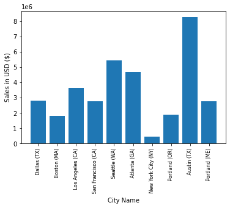

```python
import matplotlib.pyplot as plt

cities = all_months_data['city'].unique()  #This is causing the problem because its not in order

plt.bar(cities, results['Sales'])
plt.xticks(cities, rotation = 'vertical' , size = 8)
plt.ylabel('Sales in USD ($)')
plt.xlabel('City Name')
plt.show()
```

```python
#We will use a List Comprehension for Cities
```

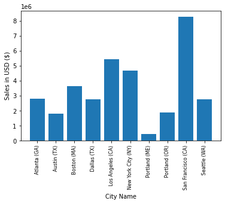

```python
import matplotlib.pyplot as plt

cities = [city for city, df in all_months_data.groupby('city')] #This will give the cities in the same order as they were in the group by sum()

plt.bar(cities, results['Sales'])
plt.xticks(cities, rotation = 'vertical' , size = 8)
plt.ylabel('Sales in USD ($)')
plt.xlabel('City Name')
plt.show()
```

#### Above Output chart is CORRECT representation of the Group by "city" sum()

**Observation**

- San Francisco is the Best performing City of Keith Super Duper cool Electronica

### What time should we display Advertisements to maximise the Likelihood of Customers buying the Product

```python
#Lets look at the data first
```

```python
all_months_data.head(3)
```

|  | Order ID | Product | Quantity Ordered | Price Each | Order Date | Purchase Address | Order Date_Month | Sales | city |
| --- | --- | --- | --- | --- | --- | --- | --- | --- | --- |
| 0 | 176558 | USB-C Charging Cable | 2 | 11.95 | 2019-04-19 | 917 1st St, Dallas, TX 75001 | 4 | 23.90 | Dallas (TX) |
| 1 | 176559 | Bose SoundSport Headphones | 1 | 99.99 | 2019-04-07 | 682 Chestnut St, Boston, MA 02215 | 4 | 99.99 | Boston (MA) |
| 2 | 176560 | Google Phone | 1 | 600.00 | 2019-04-12 | 669 Spruce St, Los Angeles, CA 90001 | 4 | 600.00 | Los Angeles (CA) |

```python
all_data = pd.read_csv('all_data.csv')
```

```python
all_data.head(2)
```

|  | Order ID | Product | Quantity Ordered | Price Each | Order Date | Purchase Address |
| --- | --- | --- | --- | --- | --- | --- |
| 0 | 176558 | USB-C Charging Cable | 2 | 11.95 | 4/19/19 8:46 | 917 1st St, Dallas, TX 75001 |
| 1 | 176559 | Bose SoundSport Headphones | 1 | 99.99 | 4/7/19 10:30 | 682 Chestnut St, Boston, MA 02215 |

```python
#Converting Order Date to datetime object so we can apply datetime functions
```

```python
all_data.drop(all_data.index[all_data['Order ID'].str.lower().str.contains('order')], inplace = True)
```

```python
all_data['Order Date'] = pd.to_datetime(all_data['Order Date'])
```

```python
all_data.head(3)
```

|  | Order ID | Product | Quantity Ordered | Price Each | Order Date | Purchase Address |
| --- | --- | --- | --- | --- | --- | --- |
| 0 | 176558 | USB-C Charging Cable | 2 | 11.95 | 2019-04-19 08:46:00 | 917 1st St, Dallas, TX 75001 |
| 1 | 176559 | Bose SoundSport Headphones | 1 | 99.99 | 2019-04-07 10:30:00 | 682 Chestnut St, Boston, MA 02215 |
| 2 | 176560 | Google Phone | 1 | 600 | 2019-04-12 02:38:00 | 669 Spruce St, Los Angeles, CA 90001 |

```python
#Add Hour column to the Data

all_data['Hour'] = all_data['Order Date'].dt.hour

all_data['Minute'] = all_data['Order Date'].dt.minute

all_data.head(2)
```

|  | Order ID | Product | Quantity Ordered | Price Each | Order Date | Purchase Address | Hour | Minute |
| --- | --- | --- | --- | --- | --- | --- | --- | --- |
| 0 | 176558 | USB-C Charging Cable | 2 | 11.95 | 2019-04-19 08:46:00 | 917 1st St, Dallas, TX 75001 | 8 | 46 |
| 1 | 176559 | Bose SoundSport Headphones | 1 | 99.99 | 2019-04-07 10:30:00 | 682 Chestnut St, Boston, MA 02215 | 10 | 30 |

```python
#If we group by "Hour" and count()

all_data.groupby(['Hour']).count()
```

| Hour | Order ID | Product | Quantity Ordered | Price Each | Order Date | Purchase Address | Minute |
| --- | --- | --- | --- | --- | --- | --- | --- |
| 1 | 14479 | 14479 | 14479 | 14479 | 14479 | 14479 | 14479 |
| 2 | 12227 | 12227 | 12227 | 12227 | 12227 | 12227 | 12227 |
| 3 | 11006 | 11006 | 11006 | 11006 | 11006 | 11006 | 11006 |
| 4 | 11238 | 11238 | 11238 | 11238 | 11238 | 11238 | 11238 |
| 5 | 12220 | 12220 | 12220 | 12220 | 12220 | 12220 | 12220 |
| 6 | 14762 | 14762 | 14762 | 14762 | 14762 | 14762 | 14762 |
| 7 | 16916 | 16916 | 16916 | 16916 | 16916 | 16916 | 16916 |
| 8 | 18484 | 18484 | 18484 | 18484 | 18484 | 18484 | 18484 |
| 9 | 19669 | 19669 | 19669 | 19669 | 19669 | 19669 | 19669 |
| 10 | 19766 | 19766 | 19766 | 19766 | 19766 | 19766 | 19766 |
| 11 | 18686 | 18686 | 18686 | 18686 | 18686 | 18686 | 18686 |
| 12 | 16497 | 16497 | 16497 | 16497 | 16497 | 16497 | 16497 |

```python
#If we plot the same thing below
```

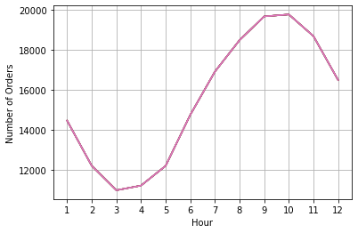

```python
hours = [hour for hour, df in  all_data.groupby('Hour')] #These will be the Hours Labels

#This time we will make the graph look more continuous , so we will use a Line Chart

plt.plot(hours, all_data.groupby(['Hour']).count())   #We are just counting the number of Rows
plt.xticks(hours)
plt.xlabel('Hour')
plt.ylabel('Number of Orders')
plt.grid()
plt.show()
```

### Question : What Products are often Sold together

```python
all_months_data.head(5)
```

|  | Order ID | Product | Quantity Ordered | Price Each | Order Date | Purchase Address | Order Date_Month | Sales | city |
| --- | --- | --- | --- | --- | --- | --- | --- | --- | --- |
| 0 | 176558 | USB-C Charging Cable | 2 | 11.95 | 2019-04-19 | 917 1st St, Dallas, TX 75001 | 4 | 23.90 | Dallas (TX) |
| 1 | 176559 | Bose SoundSport Headphones | 1 | 99.99 | 2019-04-07 | 682 Chestnut St, Boston, MA 02215 | 4 | 99.99 | Boston (MA) |
| 2 | 176560 | Google Phone | 1 | 600.00 | 2019-04-12 | 669 Spruce St, Los Angeles, CA 90001 | 4 | 600.00 | Los Angeles (CA) |
| 3 | 176560 | Wired Headphones | 1 | 11.99 | 2019-04-12 | 669 Spruce St, Los Angeles, CA 90001 | 4 | 11.99 | Los Angeles (CA) |
| 4 | 176561 | Wired Headphones | 1 | 11.99 | 2019-04-30 | 333 8th St, Los Angeles, CA 90001 | 4 | 11.99 | Los Angeles (CA) |

```python
#Basically we want to check all the Duplicate Order IDs to understand which products were sold together the most.
```

```python
#This will check Order ID column to check which ones are Duplicated, then we say keep = False
#keep = False is to keep eveything otherwise it will show only unique Duplicates
#You may check the shape of the df before adding the attribute "keep = False" to understand better
```

```python
df = all_months_data[all_months_data['Order ID'].duplicated(keep = False)]

df.head(5)
```

|  | Order ID | Product | Quantity Ordered | Price Each | Order Date | Purchase Address | Order Date_Month | Sales | city |
| --- | --- | --- | --- | --- | --- | --- | --- | --- | --- |
| 2 | 176560 | Google Phone | 1 | 600.00 | 2019-04-12 | 669 Spruce St, Los Angeles, CA 90001 | 4 | 600.00 | Los Angeles (CA) |
| 3 | 176560 | Wired Headphones | 1 | 11.99 | 2019-04-12 | 669 Spruce St, Los Angeles, CA 90001 | 4 | 11.99 | Los Angeles (CA) |
| 17 | 176574 | Google Phone | 1 | 600.00 | 2019-04-03 | 20 Hill St, Los Angeles, CA 90001 | 4 | 600.00 | Los Angeles (CA) |
| 18 | 176574 | USB-C Charging Cable | 1 | 11.95 | 2019-04-03 | 20 Hill St, Los Angeles, CA 90001 | 4 | 11.95 | Los Angeles (CA) |
| 29 | 176585 | Bose SoundSport Headphones | 1 | 99.99 | 2019-04-07 | 823 Highland St, Boston, MA 02215 | 4 | 99.99 | Boston (MA) |

```python
df.shape
```

```
(7513, 9)
```

```python
#We will try to get the products bought together displayed in the same Line
#We will group by the Order ID from our Filtered df (duplicates).
#We will specifically be looking at within the Order ID is the Product column
#And then we will use a function called "transform"
#transform is function like it takes lambda x and you can eid actual cell contents
#So, for all the Order IDs that are grouped together , sor each one of those , we are going to do some "join(x)"
```

```python
df['grouped'] = df.groupby('Order ID')['Product'].transform(lambda x: ','.join(x))
```

```python
df.head(2)
```

|  | Order ID | Product | Quantity Ordered | Price Each | Order Date | Purchase Address | Order Date_Month | Sales | city | grouped |
| --- | --- | --- | --- | --- | --- | --- | --- | --- | --- | --- |
| 2 | 176560 | Google Phone | 1 | 600.00 | 2019-04-12 | 669 Spruce St, Los Angeles, CA 90001 | 4 | 600.00 | Los Angeles (CA) | Google Phone,Wired Headphones |
| 3 | 176560 | Wired Headphones | 1 | 11.99 | 2019-04-12 | 669 Spruce St, Los Angeles, CA 90001 | 4 | 11.99 | Los Angeles (CA) | Google Phone,Wired Headphones |

```python
#Above we see problem , we can see duplicated rows of "grouped" column
#We shall go ahead and drop out those Duplicated occurances
```

```python
#Here we are dropping the duplicates and returning the dataset with just 2 columns : Order ID and grouped

df = df[['Order ID', 'grouped']].drop_duplicates()
```

```python
df.head(5)
```

|  | Order ID | grouped |
| --- | --- | --- |
| 2 | 176560 | Google Phone,Wired Headphones |
| 17 | 176574 | Google Phone,USB-C Charging Cable |
| 29 | 176585 | Bose SoundSport Headphones,Bose SoundSport Hea... |
| 31 | 176586 | AAA Batteries (4-pack),Google Phone |
| 118 | 176672 | Lightning Charging Cable,USB-C Charging Cable |

```python
df.shape
```

```
(7136, 2)
```

```python
#Now we will use some more libraries to count the items in grouped
#We will follow this technique as below for the grouped column
#The Ouput is a Dictionary
```

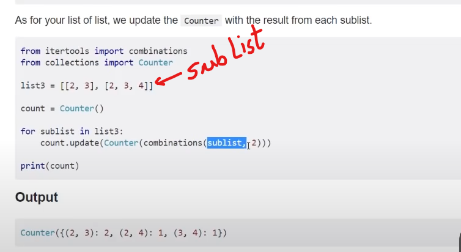

```python
#Import necessary Libraries
#Have a counter

from itertools import combinations
from collections import Counter

count = Counter()

for row in df['grouped']:    #This will get us each one of the enties in grouped column
    row_list = row.split(',') #Now we are getting a Sub-list
    count.update(Counter(combinations(row_list,2))) #Then we can copy the format with counter, our own variable Name : "count"


print(count)
```

```
Counter({('iPhone', 'Lightning Charging Cable'): 1005, ('Google Phone', 'USB-C Charging Cable'): 987, ('iPhone', 'Wired Headphones'): 447, ('Google Phone', 'Wired Headphones'): 414, ('Vareebadd Phone', 'USB-C Charging Cable'): 361, ('iPhone', 'Apple Airpods Headphones'): 360, ('Google Phone', 'Bose …
```

```python
#We will do a little formatting for the above output
#We use the "most_common" method

count.most_common(10)
```

```
[(('iPhone', 'Lightning Charging Cable'), 1005),
 (('Google Phone', 'USB-C Charging Cable'), 987),
 (('iPhone', 'Wired Headphones'), 447),
 (('Google Phone', 'Wired Headphones'), 414),
 (('Vareebadd Phone', 'USB-C Charging Cable'), 361),
 (('iPhone', 'Apple Airpods Headphones'), 360),
 (('Google Phone', 'Bose SoundSport Headphones'), 220),
 (('USB-C Charging Cable', 'Wired Headphones'), 160),
 (('Vareebadd Phone', 'Wired Headphones'), 143),
 (('Lightning Charging Cable', 'Wired Headphones'), 92)]
```

```python
#If you want to have a more readable version of the above output

for key, value in count.most_common(10):
    print(key,value)
```

```
('iPhone', 'Lightning Charging Cable') 1005
('Google Phone', 'USB-C Charging Cable') 987
('iPhone', 'Wired Headphones') 447
('Google Phone', 'Wired Headphones') 414
('Vareebadd Phone', 'USB-C Charging Cable') 361
('iPhone', 'Apple Airpods Headphones') 360
('Google Phone', 'Bose SoundSport Headphones') 220
('USB-C Charging Cable', 'Wired Headphones') 160
('Vareebadd Phone', 'Wired Headphones') 143
('Lightning Charging Cable', 'Wired Headphones') 92
```

```python
#If we want to see most common 3 in a Row

#Import necessary Libraries
#Have a counter

from itertools import combinations
from collections import Counter

count = Counter()

for row in df['grouped']:    #This will get us each one of the enties in grouped column
    row_list = row.split(',') #Now we are getting a Sub-list
    count.update(Counter(combinations(row_list,3))) #Then we can copy the format with counter, our own variable Name : "count"


for key, value in count.most_common(10):
    print(key,value)
```

```
('Google Phone', 'USB-C Charging Cable', 'Wired Headphones') 87
('iPhone', 'Lightning Charging Cable', 'Wired Headphones') 62
('iPhone', 'Lightning Charging Cable', 'Apple Airpods Headphones') 47
('Google Phone', 'USB-C Charging Cable', 'Bose SoundSport Headphones') 35
('Vareebadd Phone', 'USB-C Charging Cable', 'Wired Headphones') 33
('iPhone', 'Apple Airpods Headphones', 'Wired Headphones') 27
('Google Phone', 'Bose SoundSport Headphones', 'Wired Headphones') 24
('Vareebadd Phone', 'USB-C Charging Cable', 'Bose SoundSport Headphones') 16
('USB-C Charging Cable', 'Bose SoundSport Headphones', 'Wired Headphones') 5
('Vareebadd Phone', 'Bose SoundSport Headphones', 'Wired Headphones') 5
```

**Observations**

- So what can we do with this ?
- May be try to be smart with Promotions
- Create some smart deals
- May be use these combinations to your advantage
- This output would help business make decisions like that

### Question : What Product sold the most? Why do you think it sold the most?

```python
#we start off with the groupby
#For getting "What Product sold the most" , we need to sum up the Quantity ordered and start grouping by the Product
```

```python
product_group = all_months_data.groupby('Product')

#Lets look at product_group.sum()

product_group.sum()
```

| Product | Quantity Ordered | Price Each | Order Date_Month | Sales |
| --- | --- | --- | --- | --- |
| 20in Monitor | 4129 | 451068.99 | 29336 | 454148.71 |
| 27in 4K Gaming Monitor | 6244 | 2429637.70 | 44440 | 2435097.56 |
| 27in FHD Monitor | 7550 | 1125974.93 | 52558 | 1132424.50 |
| 34in Ultrawide Monitor | 6199 | 2348718.19 | 43304 | 2355558.01 |
| AA Batteries (4-pack) | 27635 | 79015.68 | 145558 | 106118.40 |
| AAA Batteries (4-pack) | 31017 | 61716.59 | 146370 | 92740.83 |
| Apple Airpods Headphones | 15661 | 2332350.00 | 109477 | 2349150.00 |
| Bose SoundSport Headphones | 13457 | 1332366.75 | 94113 | 1345565.43 |
| Flatscreen TV | 4819 | 1440000.00 | 34224 | 1445700.00 |
| Google Phone | 5532 | 3315000.00 | 38305 | 3319200.00 |
| LG Dryer | 646 | 387600.00 | 4383 | 387600.00 |
| LG Washing Machine | 666 | 399600.00 | 4523 | 399600.00 |
| Lightning Charging Cable | 23217 | 323787.10 | 153092 | 347094.15 |
| Macbook Pro Laptop | 4728 | 8030800.00 | 33548 | 8037600.00 |
| ThinkPad Laptop | 4130 | 4127958.72 | 28950 | 4129958.70 |
| USB-C Charging Cable | 23975 | 261740.85 | 154819 | 286501.25 |
| Vareebadd Phone | 2068 | 826000.00 | 14309 | 827200.00 |
| Wired Headphones | 20557 | 226395.18 | 133397 | 246478.43 |
| iPhone | 6849 | 4789400.00 | 47941 | 4794300.00 |

```python
#We can use the Quantity ordered to figure out the best things
#Then we can use this output for visualizing the data
#We just want to look at 'Quantity Ordered' for the  product_group
quantity_ordered = product_group.sum()['Quantity Ordered']
```

```python
quantity_ordered.head(5)
```

```
Product
20in Monitor               4129
27in 4K Gaming Monitor     6244
27in FHD Monitor           7550
34in Ultrawide Monitor     6199
AA Batteries (4-pack)     27635
Name: Quantity Ordered, dtype: int32
```

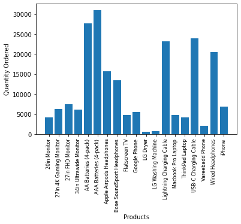

```python
#We will make a BAR chart again

products = [product for product, df in product_group]

plt.bar(products, quantity_ordered)  #x-axis will be the products and y-axis will be the quantity_ordered
plt.xticks(products, rotation = 'vertical' , size = 8)
plt.ylabel('Quantity Ordered')
plt.xlabel('Products')
plt.show()
```

**Observation**

- Looks like AAA batteries were the hottest selling items .
- The Other items sold the most are Lightening Charging Cables , USB-C Charging Cables, AA betteries
- Why will that be more than the Washing machines ....well the immediate reaction I have is, because those items are cheap.
- That is probably the reason why this is lot higher than the other ones.
- But as Data Scientist , we would want to prove our hypothesis

So to prove our hypothesis , we could overlay this graph with may be the Actual prices of these items and see if there is a Direct Correlation.

```python
#We could group by the Product : all_months_data.groupby('Product')
#We use the mean()
#We want the mean of Price , we get the Avg price these things are sold for

prices = all_months_data.groupby('Product').mean()['Price Each']

print(prices)
```

```
Product
20in Monitor                   109.99
27in 4K Gaming Monitor         389.99
27in FHD Monitor               149.99
34in Ultrawide Monitor         379.99
AA Batteries (4-pack)            3.84
AAA Batteries (4-pack)           2.99
Apple Airpods Headphones       150.00
Bose SoundSport Headphones      99.99
Flatscreen TV                  300.00
Google Phone                   600.00
LG Dryer                       600.00
LG Washing Machine             600.00
Lightning Charging Cable        14.95
Macbook Pro Laptop            1700.00
ThinkPad Laptop                999.99
USB-C Charging Cable            11.95
Vareebadd Phone                400.00
Wired Headphones                11.99
iPhone                         700.00
Name: Price Each, dtype: float64
```

#### Now we want to overlay this data on the chart and add a secondary y-axis but keep the same x-labels

```python
#Search google : Add a secondary y-axis to a Matplitlib chart
#This is the solution given by Stack overflow
```

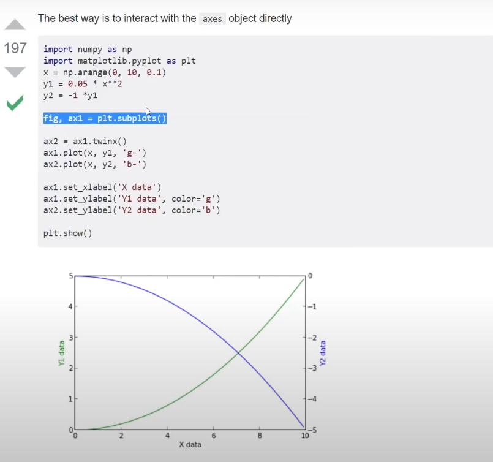

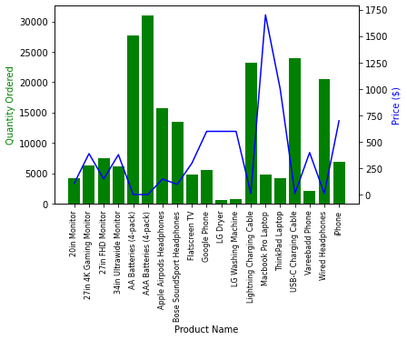

```python
#I'm going to plot a Sub-plot
#We can copy and paste the same Code
#Here instead of x and y , we will use our data
# x= products , y1 = quantity_ordered , y2 = prices

prices = all_months_data.groupby('Product').mean()['Price Each']

fig, ax1 = plt.subplots()

ax2 = ax1.twinx()
ax1.bar(products, quantity_ordered, color='g')
ax2.plot(products, prices, 'b-')

ax1.set_xlabel('Product Name')
ax1.set_ylabel('Quantity Ordered', color ='g')
ax2.set_ylabel('Price ($)', color='b')
ax1.set_xticklabels(products, rotation = 'vertical', size = 8)

plt.show()
```

So, if the Price and Quantiy Ordered Kind of correlates then we kind of Prove our Hypothesis

- Whenever the Quantity orederd is high , the Price should be low
- We see that , it is the case for AAA and AA batteries
- Then you can look at some inconsitencies as well.
- You can say the Price is very high for the Macbook Pro Laptop , then why is the Quantity Ordered so much higher than the LG dryr and Washing machine.
- Well, there is more demand for MAC Book PRO

➖➖➖ ➖➖➖➖➖ ➖➖➖ ➖➖➖ ➖➖➖ ➖➖➖ ➖➖➖ ➖➖➖ ➖➖➖ ➖➖➖ ➖➖➖

### Comments

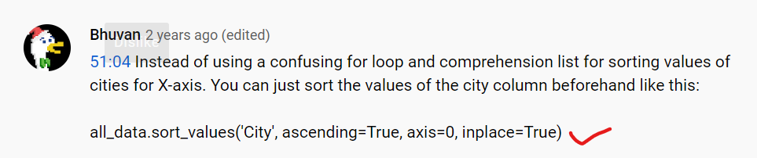

[figure not shown]